# How to Pull the Right Lever

School Attainment, Open Data Analytics and Local Education Policy in England — Lessons from Brighton and Hove

Adam Dennett

Bartlett Centre for Advanced Spatial Analysis, UCL

2026-10-14

## Headlines

- Over the last 4-years, after accounting for structural factors, Brighton and Hove ranks (out of 152 LEAs):
  - **7th BEST** for Disadvantaged GCSE Attainment
  - **5th BEST** for Non-Disadvantaged GCSE Attainment
- Last year, Brighton and Hove was **2nd WORST** for absence.
- GCSE Attainment is very predictable at School Level - 80% variation explained by a handful of variables
- The biggest factor affecting disadvantaged student attainment is absence
- Data shows disadvantaged students in England do better in schools with more disadvantaged students in
- Poor understanding of evidence –> poor policy –> poor parental choices

# Motivation

## The problem

- The UK Government’s **2026 Schools White Paper** targets halving the disadvantage attainment gap
- Achieving this requires LEAs to understand **local drivers** of attainment
- A crucial gap exists between **open data availability** and **accessible, contextualised intelligence**
- This research is motivated by **direct experience** of policy development in Brighton and Hove in 2024–25

**The risk:** Policy designed around an incomplete understanding of local attainment drivers can pull the wrong lever — doing little good and potentially causing harm.

**Our aim:** Show that DfE open data + multilevel models can explain ~80% of attainment variation — enough to transform local policy conversations.

## What drives attainment at GCSE? The literature

- **Attendance**: strongest predictor — persistently absent pupils: 36% pass rate vs 84% for full attenders (DfE, 2022, 2025)
- **Prior attainment** at KS2: reflects accumulated earlier inequalities (Gorard and Siddiqui, 2019; Stopforth and Gayle, 2025)
- **Disadvantage** (FSM): some residual effect remains after accounting for above. Gap narrowed post-2011, reversed post-COVID (Tuckett et al., 2023)
- **Workforce**: leadership quality, teacher retention, and teacher sickness matter — especially for disadvantaged pupils (Gibbons et al., 2018; Menzies, 2023; Zuccollo et al., 2023)
- **Selectivity**: creams-off rather than improves - grammar school premium largely disappears after SES controls (Anders et al., 2024; Gorard et al., 2022; Gorard and Siddiqui, 2019)
- **Individual Pupil characteristics** (Houtepen et al., 2020; O’Connell and Marks, 2022)

The factors are **multifaceted, complex and interrelated**. What’s needed is an analysis combining them so their relative importance can be assessed concurrently.

# Data and Model

## What is the ‘model’?

- Statistical explanation of how GCSE Attainment varies between schools after accounting for things we know affect attainment
- Raw league tables compare finishing positions, our model adjusts for the wind

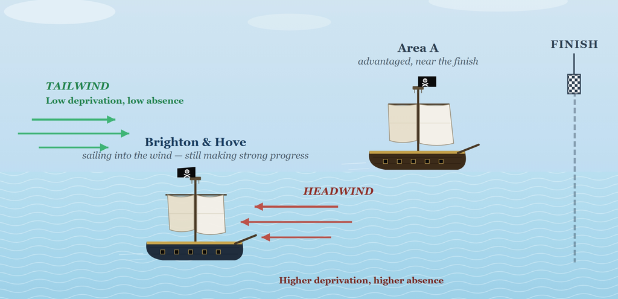

## Model specification

**4-year panel** (2021–22 to 2024–25): ~12,200 school-year observations from 3,523 schools across 152 LEAs.

**Multilevel LME** with log-transformed Attainment 8:

$$\log(\text{ATT8}_{ij}) = \beta_0 + \sum_{k=1}^{9} \beta_k \, x_{kij} + u_{\text{year}} + u_{\text{Ofsted}} + u_{\text{region}} + u_{\text{LA|region}} + \varepsilon_{ij}$$

**Fixed effects:** log(%FSM), log(%Absence), log(%EAL), %Low prior attainment, Selective admissions, Gorard Segregation Index, Teacher retention, Leadership pay %, log(Teacher sickness days)

**Random intercepts:** Year, Ofsted rating, Region, LA nested within region

Separate models fitted for **all pupils**, **disadvantaged**, and **non-disadvantaged** Attainment 8.

## Results: Relative Explanatory Variable Importance for Attainment 8

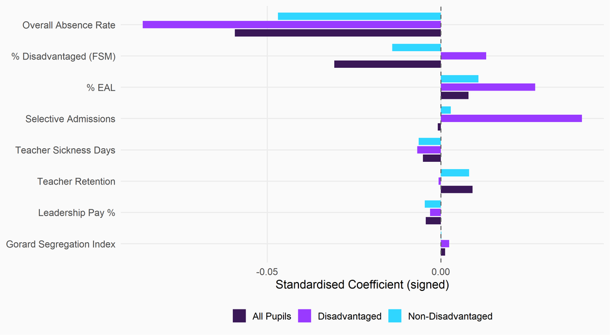

Figure 1

## Key finding: absence dominates

- For **disadvantaged pupils**, nearly half of school-level performance variation is explained by attendance alone
- Conditional R² ≈ **0.73** for disadvantaged pupils
- The Gorard Segregation Index is **not significant** once other factors are controlled for
- For disadvantaged pupils, the FSM concentration effect runs **in the opposite direction** to common assumption — they do slightly *better* in schools with higher proportions of disadvantaged students
- On the council’s own framing — *“reducing some schools’ barriers to success”* — **attendance is the largest, best-evidenced barrier** the model can quantify

Attendance is the **ultimate equity lever** — and the most accessible one for local policy.

# Brighton and Hove Case Study

## The city’s secondary school landscape

[interactive chart not shown]

Figure 2

## The 2024 consultation (1)

**What was proposed:**

- Reduce Published Admission Numbers at popular central schools
- Redraw catchment boundaries
- Reserve places for out-of-catchment children

**Council’s stated objectives** (Dec 2024 Cabinet papers):

- *“reducing some schools’ barriers to success”* for disadvantaged pupils
- *“a more mixed pupil intake creates better outcomes”*
- Stated premise: attainment *“driven by economic advantage”*

## The 2024 consultation (2)

**The response:**

- Overwhelmingly negative from parents and schools
- “Strong preference for improving existing schools rather than redistributing students”
- Proposals would force significant numbers of children into 2+ hour daily commutes

Detailed local data and analytics were **not available** at the time of the consultation. The city was painted as a failure — but was it?

## How is Brighton & Hove actually performing?

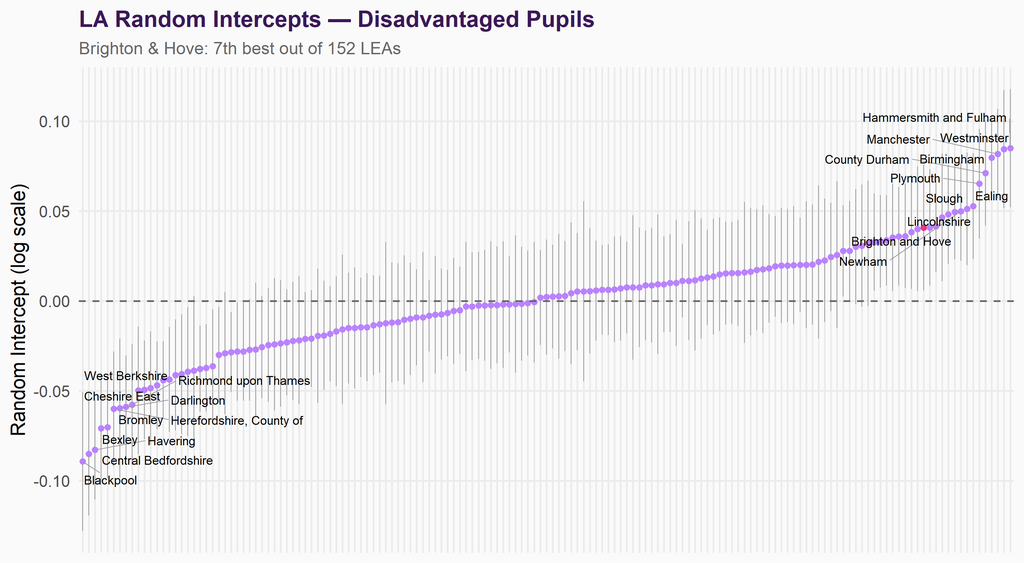

Figure 3

## Brighton & Hove: a story of success, not failure

**LEA rankings (after structural adjustment):**

| Pupil group | Rank / 152 |
| --- | --- |
| Disadvantaged | **7th** |
| Non-disadvantaged | **5th** |
| All pupils | **4th** |

The positive random intercept ≈ **+2 GCSE points** above what structural factors predict.

**This was entirely unknown** at the time of the 2024 consultation and completely absent from the public narrative.

The starting point was a narrative of *failure*. The evidence says the opposite: this is one of the **highest-performing LEAs in England**.

Rather than “what is the city doing wrong?”, the question should be **“what is it doing right?”**

## But there is a problem — and it isn’t segregation

**FSM (the lever they chose):**

- City mean: 28.8%
- National mean: 28.3%
- National percentile: **52th**
- *Completely unremarkable*

**Absence (the lever they ignored):**

- City mean: 10.8%
- National mean: 8.2%
- National percentile: **99th**
- *Among the very worst in England*

Brighton & Hove has **near-average disadvantage** but **near-worst absence**. The city’s strong underlying performance is being dragged down by an absence problem at the extreme of the national distribution.

## Accelerating returns: comparing the two levers

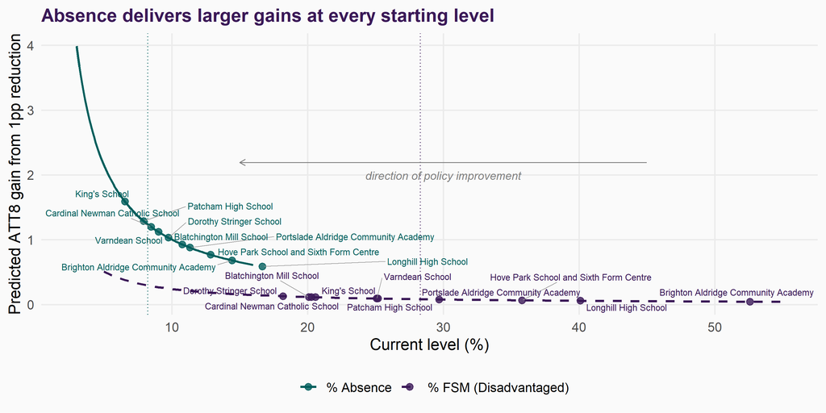

Figure 4

## What would closing the absence gap deliver?

Table 1

| School | Current Absence % | National Avg (Target) | Reduction (pp) | ATT8 gain (all) | ATT8 gain (disadv.) |
| --- | --- | --- | --- | --- | --- |
| Longhill High School | 16.7 | 8.2 | 8.4 | 5.2 | 6.0 |
| Brighton Aldridge Community Academy | 14.4 | 8.2 | 6.2 | 4.5 | 6.1 |
| Hove Park School and Sixth Form Centre | 12.9 | 8.2 | 4.6 | 4.0 | 4.7 |
| Portslade Aldridge Community Academy | 11.3 | 8.2 | 3.1 | 2.9 | 3.1 |
| Blatchington Mill School | 10.8 | 8.2 | 2.6 | 2.9 | 3.2 |
| Dorothy Stringer School | 9.8 | 8.2 | 1.5 | 1.9 | 1.9 |
| Varndean School | 9.0 | 8.2 | 0.8 | 0.9 | 0.9 |
| Cardinal Newman Catholic School | 8.5 | 8.2 | 0.3 | 0.3 | 0.4 |

Bringing absence to the national average → predicted gains of **3–5 GCSE points** at the worst-affected schools. FSM reductions → closer to **1–2 points**.

## Observed vs predicted: disadvantaged pupils nationally (2024–25)

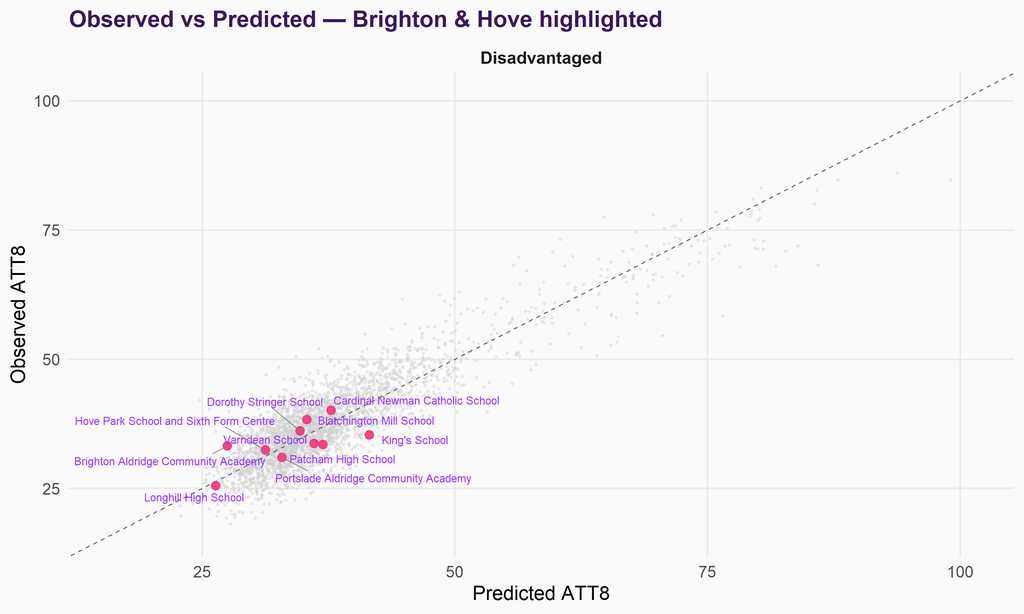

Figure 5

## The BACA paradox

**What people thought:**

- ‘Requires Improvement’ Ofsted
- Low raw attainment scores
- **→ narrative of “Avoid this school”**
- Equity in Education campaign: parents opt for Patcham instead

**What the data shows:**

- **Best performing school in the city** for disadvantaged pupils
- +5 GCSE points above national peers (2024–25)
- April 2025: Ofsted upgraded to **‘Good’** in all areas

**Patcham — “the safer choice”:**

- Rated ‘Good’ by Ofsted
- Comfortable mid-table in raw terms
- But **negative value-added** for disadvantaged pupils
- 4-year average: **–2.6 GCSE points**

Parents, acting rationally on available information, may have been choosing the school with *lower* value-added for their children — if that is the most important factor. They were operating in a **knowledge vacuum**.

## Absence isn’t just one number

- Absence is the single biggest predictor of attainment — but it sits in **two roles** at once
  - Part is **structural** (intake, area health, deprivation, family circumstances)
  - Part is **school-managed** (pastoral systems, attendance practice)
- A two-stage decomposition<sup>1</sup> separates them, giving each school a **value-added** *and* a **residual absence** indicator
- Most absence variance nationally is structural; school-controllable share is the smaller part — but it’s the one local policy can actually move

Closing a city’s absence problem needs **both** school-level attention **and** cross-departmental work — public health, children’s services, area deprivation policy. Schools cannot fix the structural component alone.

[^1]: Full analysis: https://adamdennett.github.io/school_attainment_tool/model_experiments.html#sec-two-stage-absence

## Brighton and Hove on the joint-signal plane

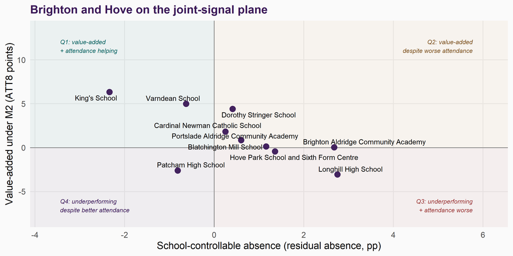

Figure 6

# The Policy Simulator Tool

## Bridging the gap

**What it does:**

- Search for **any school** in England
- See key statistics and contextual benchmarks
- Compare **observed vs predicted** attainment
- **Simulate** the impact of changes to absence, FSM, workforce etc.
- Explore **LA-level** patterns and typologies
- Find a school’s contextual **“twin”**

**Built with:**

- R Shiny
- Same multilevel models as this analysis
- DfE open data (updated annually)
- Development accelerated by **Claude** (Anthropic) — AI4CI funded

Not the finished article — but a demonstration of what’s possible when open data + appropriate methods + accessible tools come together.

## The simulator in action

[figure not shown]

School Finder → select any school → view contextual statistics → send to the Policy Simulator

[adam-dennett.shinyapps.io/School_Attainment_Policy_Simulator](https://adam-dennett.shinyapps.io/School_Attainment_Policy_Simulator/)

## Adjusting policy levers

[figure not shown]

Non-linear effects mean the same adjustment produces **different impacts** depending on the school’s starting position

# Neighbourhoods and the Limits of School Effects

## Where variation in Attainment 8 comes from

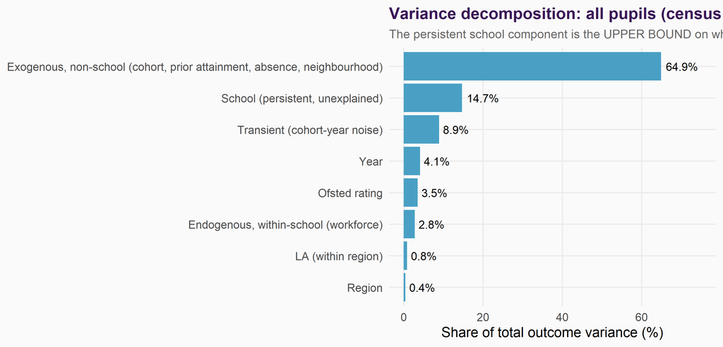

## The same picture for disadvantaged pupils

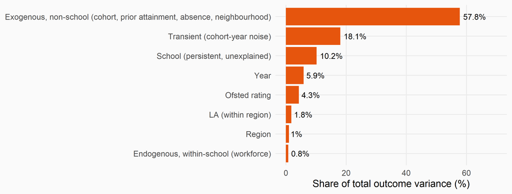

# Discussion

## The danger of single-lever policy thinking

1. The council’s proposals were built on a **single causal narrative**: redistribute disadvantaged pupils to narrow the gap
2. Concentrations of disadvantage are one of the **weaker** available levers
3. For disadvantaged pupils specifically, the effect runs **counter** to the policy assumptions
4. Longer journeys from redistribution → **higher absence** — worsening the factor that most drags on attainment
5. The claim that social mixing can be achieved at ‘almost no cost’ **overlooks second-order effects**
6. Brighton & Hove’s schools are already in the **top third for integration** — yet policy sought to mix them further

## Recommendations

**For the DfE:**

- Invest in **analytical infrastructure** at the local level
- Fund **LA analytical capacity** or develop nationally maintained benchmarking tools
- Go **beyond raw league tables**

**For LEAs:**

- **Resist single causal narratives**
- Create institutional space for **genuine deliberation** before irreversible decisions
- Prioritise **attendance** as a policy lever

**For schools, governors & parents:**

- **Contextualised benchmarking** offers a fairer basis than raw scores
- Demand **better information** before making choices
- School ‘quality’ ≠ raw attainment

## The final word

**The caution:** Policy made in haste, anchored to a single causal narrative and implemented without adequate regard for evidence, risks doing more harm than good — particularly when it disrupts a system that is working well.

**The encouragement:** The raw materials for better policy **already exist** in DfE open data. With the right analytical tools and a commitment to evidence over ideology, it is possible to understand what drives attainment in any local context — and where the most productive interventions lie.

**The challenge:** Ensuring this understanding reaches decision makers **before** decisions are made — not after.

## Links & resources

**The tool:**

[Policy Simulator](https://adam-dennett.shinyapps.io/School_Attainment_Policy_Simulator/)

**The analysis:**

[Full report & supplementary material](https://adamdennett.github.io/school_attainment_tool/)

**The code:**

[GitHub repository](https://github.com/adamdennett/school_attainment_tool)

**The paper:**

[JEP Paper (full version)](https://adamdennett.github.io/school_attainment_tool/pulling_the_right_lever.html)

**Contact:**

a.dennett@ucl.ac.uk

**Funding:**

[UKRI AI4CI Hub](https://ai4ci.ac.uk/) — National AI Research Hub for Collective Intelligence

All data used in this analysis are publicly available from the Department for Education. All processing code is open source.

[figure not shown]